# Final Report for Intro to Data Science

Wyatt Smith - `wsmith4725@floridapoly.edu`

# Preparation

Load in the libraries to be used. Most of the work will be done using functions form the `tidyverse` package.

```r
library(tidyverse)
```

## Import data set

```r
platforms <- read_csv("https://github.com/wsmith867/DS_Final_Project/blob/master/data/MoviesOnStreamingPlatforms_updated.csv?raw=true")
```

# Introduction

With the emergence of streaming services, it has become one of, if not, the most popular way to watch movies and/or shows. At first Netflix was the most recognizable service to use, but now there are multiple choices of platforms to stream from, with each providing its own selection of entertainment. The aim of this report is to explore and compare the different streaming platforms, from their library size to overall ratings of movies within their libraries. We will also explore other characteristics of each platform, such as exclusivity of each; given that Netflix has its own line of original movies and shows, and Disney+ would be the main platform for Disney owned movies and shows. Within the current data set, it classifies whether an entry is a movie or show, but all data entries within this data set are all movies. Thus, they will be referred to as such.

# Data Description

```r
glimpse(platforms)
```

```
Rows: 16,744
Columns: 17
$ X1                <dbl> 0, 1, 2, 3, 4, 5, 6, 7, 8, 9, 10, 11, 12, 13, 14, 15, 16, 17, 18, 19, 20, 21, 22, 23, 24, 25, 26, 27, 28, 29, 30,...
$ ID                <dbl> 1, 2, 3, 4, 5, 6, 7, 8, 9, 10, 11, 12, 13, 14, 15, 16, 17, 18, 19, 20, 21, 22, 23, 24, 25, 26, 27, 28, 29, 30, 31...
$ Title             <chr> "Inception", "The Matrix", "Avengers: Infinity War", "Back to the Future", "The Good, the Bad and the Ugly", "Spi...
$ Year              <dbl> 2010, 1999, 2018, 1985, 1966, 2018, 2002, 2012, 1981, 2009, 1976, 2009, 2006, 2015, 1975, 1968, 1989, 1993, 2010,...
$ Age               <chr> "13+", "18+", "13+", "7+", "18+", "7+", "18+", "18+", "7+", "18+", "18+", "13+", "18+", "18+", "7+", "13+", "13+"...
$ IMDb              <dbl> 8.8, 8.7, 8.5, 8.5, 8.8, 8.4, 8.5, 8.4, 8.4, 8.3, 8.3, 8.4, 8.2, 8.1, 8.2, 8.5, 8.2, 8.0, 8.0, 8.0, 8.2, 7.7, 8.0...
$ `Rotten Tomatoes` <chr> "87%", "87%", "84%", "96%", "97%", "97%", "95%", "87%", "95%", "89%", "95%", "100%", "95%", "93%", "97%", "95%", ...
$ Netflix           <dbl> 1, 1, 1, 1, 1, 1, 1, 1, 1, 1, 1, 1, 1, 1, 1, 1, 1, 1, 1, 1, 1, 1, 1, 1, 1, 1, 1, 1, 1, 1, 1, 1, 1, 1, 1, 1, 1, 1,...
$ Hulu              <dbl> 0, 0, 0, 0, 0, 0, 0, 0, 0, 0, 0, 0, 0, 0, 0, 0, 0, 0, 0, 0, 0, 0, 0, 0, 0, 0, 0, 0, 0, 0, 0, 0, 0, 0, 0, 0, 0, 0,...
$ `Prime Video`     <dbl> 0, 0, 0, 0, 1, 0, 1, 0, 0, 0, 0, 1, 0, 0, 0, 1, 0, 0, 0, 0, 0, 0, 0, 0, 0, 0, 0, 0, 0, 0, 0, 1, 1, 0, 0, 0, 0, 0,...
$ `Disney+`         <dbl> 0, 0, 0, 0, 0, 0, 0, 0, 0, 0, 0, 0, 0, 0, 0, 0, 0, 0, 0, 0, 0, 0, 0, 0, 0, 0, 0, 0, 0, 0, 0, 0, 0, 0, 0, 0, 0, 0,...
$ Type              <dbl> 0, 0, 0, 0, 0, 0, 0, 0, 0, 0, 0, 0, 0, 0, 0, 0, 0, 0, 0, 0, 0, 0, 0, 0, 0, 0, 0, 0, 0, 0, 0, 0, 0, 0, 0, 0, 0, 0,...
$ Directors         <chr> "Christopher Nolan", "Lana Wachowski,Lilly Wachowski", "Anthony Russo,Joe Russo", "Robert Zemeckis", "Sergio Leon...
$ Genres            <chr> "Action,Adventure,Sci-Fi,Thriller", "Action,Sci-Fi", "Action,Adventure,Sci-Fi", "Adventure,Comedy,Sci-Fi", "Weste...
$ Country           <chr> "United States,United Kingdom", "United States", "United States", "United States", "Italy,Spain,West Germany", "U...
$ Language          <chr> "English,Japanese,French", "English", "English", "English", "Italian", "English,Spanish", "English,German,Russian...
$ Runtime           <dbl> 148, 136, 149, 116, 161, 117, 150, 165, 115, 153, 114, 170, 118, 118, 91, 165, 127, 101, 118, 126, 158, 120, 117,...
```

| Variable | Description |
| --- | --- |
| `Title` | Title name |
| `Year` | Year produced |
| `Age` | Target age group |
| `IMDb` | IMDb rating |
| `Rotten Tomatoes` | Rotten tomatoes rating |
| `Netflix` | Whether the movie is found on Netflix |
| `Hulu` | Whether the movie is found on Hulu |
| `Prime Video` | Whether the movie is found on Prime Video |
| `Disney+` | Whether the movie is found on Disney+ |
| `Type` | Movie or TV series |
| `Directors` | Directors Name |
| `Genre` | Category of Movie |
| `Country` | Country |
| `Language` | Language available in |
| `Runtime` | Duration in minutes |

According to the source of the data set, it was found that Rotten Tomatoes had 69% of its values as NA values, so we shall remove this variable from the data set. Given that the IMDb variable is still included, we still have a rating variable to use for data analysis.

```r
platforms <- platforms %>%
  select(c(-7))
```

```r
platforms <- na.omit(platforms)
```

To help avoid errors going forward, we will be renaming `Prime Video` and `Disney+`. Plus this will make it easier to type out the full variable name if need be.

```r
platforms <- platforms %>%
  rename(PrimeVideo = `Prime Video`,
         DisneyP = `Disney+`)
```

# Data Exploration

```r
platforms %>%
  head(10)
```

| X1 | ID | Title | Year | Age | IMDb | Netflix | Hulu | PrimeVideo | DisneyP | Type | Directors | Genres | Country | Language | Runtime |
| --- | --- | --- | --- | --- | --- | --- | --- | --- | --- | --- | --- | --- | --- | --- | --- |
| 0 | 1 | Inception | 2010 | 13+ | 8.8 | 1 | 0 | 0 | 0 | 0 | Christopher Nolan | Action,Adventure,Sci-Fi,Thriller | United States,United Kingdom | English,Japanese,French | 148 |
| 1 | 2 | The Matrix | 1999 | 18+ | 8.7 | 1 | 0 | 0 | 0 | 0 | Lana Wachowski,Lilly Wachowski | Action,Sci-Fi | United States | English | 136 |
| 2 | 3 | Avengers: Infinity War | 2018 | 13+ | 8.5 | 1 | 0 | 0 | 0 | 0 | Anthony Russo,Joe Russo | Action,Adventure,Sci-Fi | United States | English | 149 |
| 3 | 4 | Back to the Future | 1985 | 7+ | 8.5 | 1 | 0 | 0 | 0 | 0 | Robert Zemeckis | Adventure,Comedy,Sci-Fi | United States | English | 116 |
| 4 | 5 | The Good, the Bad and the Ugly | 1966 | 18+ | 8.8 | 1 | 0 | 1 | 0 | 0 | Sergio Leone | Western | Italy,Spain,West Germany | Italian | 161 |
| 5 | 6 | Spider-Man: Into the Spider-Verse | 2018 | 7+ | 8.4 | 1 | 0 | 0 | 0 | 0 | Bob Persichetti,Peter Ramsey,Rodney Rothman | Animation,Action,Adventure,Family,Sci-Fi | United States | English,Spanish | 117 |
| 6 | 7 | The Pianist | 2002 | 18+ | 8.5 | 1 | 0 | 1 | 0 | 0 | Roman Polanski | Biography,Drama,Music,War | United Kingdom,France,Poland,Germany | English,German,Russian | 150 |
| 7 | 8 | Django Unchained | 2012 | 18+ | 8.4 | 1 | 0 | 0 | 0 | 0 | Quentin Tarantino | Drama,Western | United States | English,German,French,Italian | 165 |
| 8 | 9 | Raiders of the Lost Ark | 1981 | 7+ | 8.4 | 1 | 0 | 0 | 0 | 0 | Steven Spielberg | Action,Adventure | United States | English,German,Hebrew,Spanish,Arabic,Nepali | 115 |
| 9 | 10 | Inglourious Basterds | 2009 | 18+ | 8.3 | 1 | 0 | 0 | 0 | 0 | Quentin Tarantino | Adventure,Drama,War | Germany,United States | English,German,French,Italian | 153 |

## Basic Exploration

Let us begin with more some overall data analysis, before focusing on the platforms themselves.

### Rating Distribution

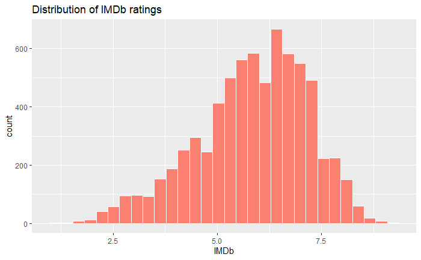

```r
platforms %>%
  ggplot(aes(x = IMDb)) +
  geom_histogram(color = 'white', fill = 'salmon') +
  labs(title = "Distribution of IMDb ratings")
```

### Movie Runtimes

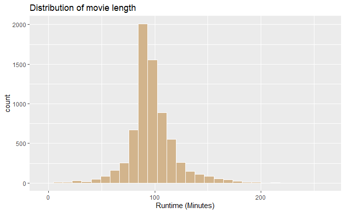

```r
platforms %>%
  ggplot(aes(x = Runtime)) +
  geom_histogram(color = 'white', fill = 'tan') +
  labs(x = "Runtime (Minutes)") +
  labs(title = "Distribution of movie length")
```

We can see that there are run time that are very short, but also run times that are very long. Let’s see what movies those are at the ends.

```r
platforms %>%
  filter(Runtime > 180) %>%
  select(3, 16) %>%
  arrange(desc(Runtime))
```

| Title | Runtime |
| --- | --- |
| The Greatest Story Ever Told | 260 |
| Lagaan: Once Upon a Time in India | 224 |
| Jatt James Bond | 220 |
| Mohabbatein | 216 |
| Jodhaa Akbar | 213 |
| Swades | 210 |
| Kabhi Khushi Kabhie Gham | 210 |
| The Irishman | 209 |
| Giant | 201 |
| Tarzan the Fearless | 200 |

[output cut: 27 more lines]

We can see that the longest movies we have here is 260 minutes long. That’s over 4 hours! But now lets see the movies on the shorter spectrum.

```r
platforms %>%
  filter(Runtime < 40) %>%
  select(3, 16) %>%
  arrange(Runtime)
```

| Title | Runtime |
| --- | --- |
| #LoveSwag | 2 |
| Luxo Jr. | 2 |
| Tin Toy | 5 |
| Christmas Comes But Once a Year | 9 |
| Kitbull | 9 |
| Big Buck Bunny | 10 |
| Bark | 11 |
| 12 Days of Christmas Eve | 11 |
| Lou | 12 |
| A Trip to the Moon | 13 |

[output cut: 52 more lines]

We have “movies” in here which are only 2 minutes long. Most of these are actually shorts that studios sometimes make, whether they are original shorts or shorts from other movies.

### Year of release Distribution

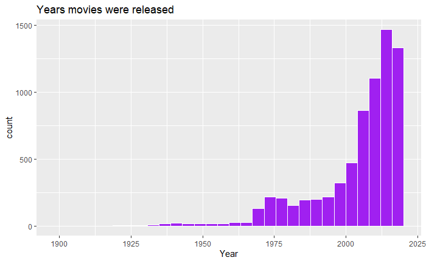

```r
platforms %>%
  ggplot(aes(x = Year)) +
  geom_histogram(color = 'white', fill = 'purple') +
  labs(title = "Years movies were released")
```

Notice how far back the year of the movie goes. And even though we don’t see any fill color, we can see that the x-axis goes as far back as 1900. Let us see what movies are that old, and how many we have.

```r
platforms %>%
  filter(Year < 1930) %>%
  select(3:5, 7:10)
```

| Title | Year | Age | Netflix | Hulu | PrimeVideo | DisneyP |
| --- | --- | --- | --- | --- | --- | --- |
| A Trip to the Moon | 1902 | all | 0 | 0 | 1 | 0 |
| The Cabinet of Dr. Caligari | 1920 | 7+ | 0 | 0 | 1 | 0 |
| The Phantom of the Opera | 1925 | 13+ | 0 | 0 | 1 | 0 |
| The Birth of a Nation | 1915 | 7+ | 0 | 0 | 1 | 0 |
| Robin Hood | 1922 | 7+ | 0 | 0 | 1 | 1 |
| Tumbleweeds | 1925 | all | 0 | 0 | 1 | 0 |
| From the Manger to the Cross | 1912 | 7+ | 0 | 0 | 1 | 0 |

So we do in fact have some pretty old movies, with one going as far back as 1902. And all but one of these films are exclusive to Prime Video.

### Targeted Age Groups

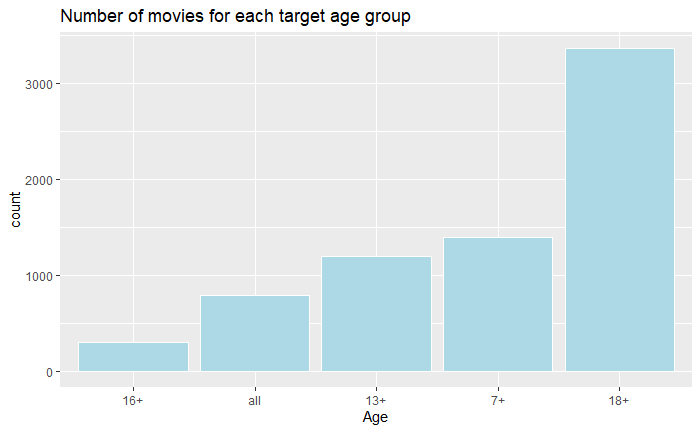

```r
platforms %>%
  mutate(Age = fct_relevel(Age, "16+", "all", "13+", "7+", "18+")) %>%
  ggplot(aes(Age)) +
  geom_bar(color = 'white', fill = 'lightblue') +
  labs(title = "Number of movies for each target age group")
```

Interesting that there is a significantly lower number of movies aimed at 16+. Most likely the reason for this is that if a movie would be targeted towards 16+ would instead be classified under 13+ or 18+.

## Platform exploration

Now we can focus on the platforms themselves, specifically on the size of their libraries.

### Library Size

In terms of just raw numbers, which streaming platform has the largest library?

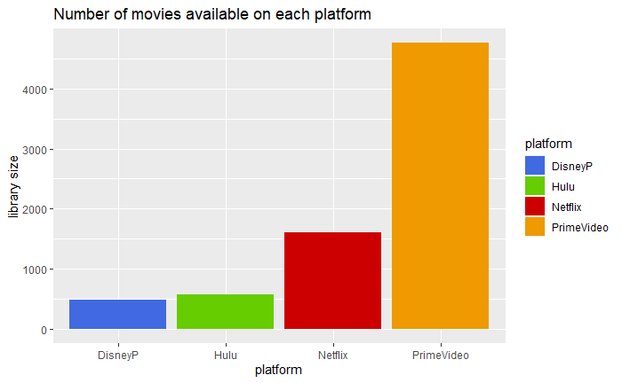

```r
platforms %>%
  gather(Netflix, Hulu, PrimeVideo, DisneyP, key = "platform", value = "value") %>%
  group_by(platform) %>%
  filter(value == 1) %>%
  ggplot(aes(x = platform, fill = platform)) +
  scale_fill_manual(values = c("royalblue", "chartreuse3", "red3", "orange2")) +
  geom_bar() +
  labs(title = "Number of movies available on each platform", y = "library size")
```